# Behavioral Analysis

### Zachary Traylor’s Master’s Thesis

Return to Main Page

## One-Way ANOVA on Pain Threshold Data

Load the Pain Threshold data. This is the level of laser stimulation (in mJ) that the subject reported as painful. Data is grouped by male and female.

```r
threshold <- read_csv("Data/Thresholds.csv", col_types = cols(Sex = col_factor(
                                                       levels = c("male", "female"))))
```

Visualize the distributions via their box plots. Also, analyze normality visually.

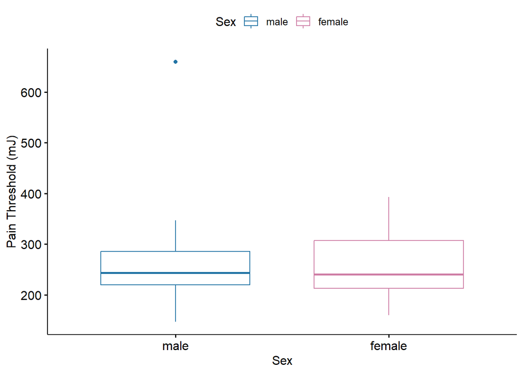

```r
ggboxplot(threshold, x = "Sex", y = "Threshold",
          color = "Sex", palette = c("#2274A5", "#CE7DA5"),
          ylab = "Pain Threshold (mJ)", xlab = "Sex")
```

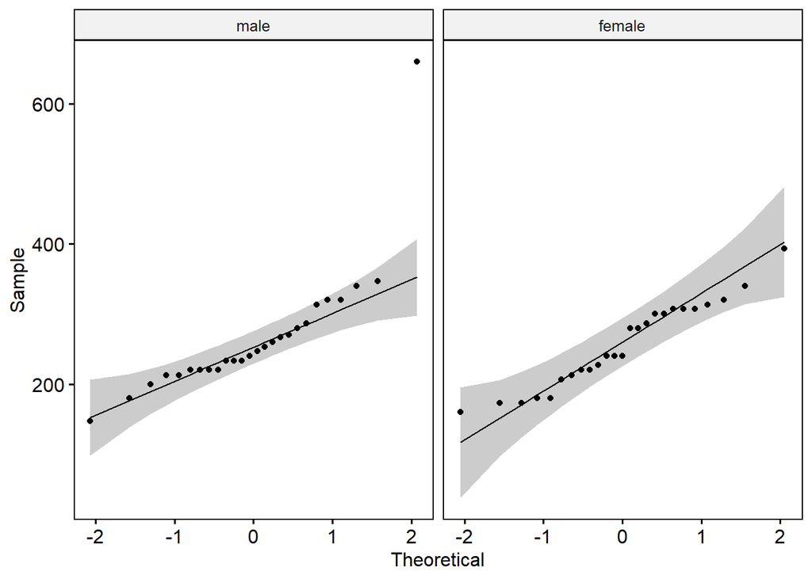

```r
ggqqplot(threshold, "Threshold", facet.by = "Sex")
```

```r
print(c("Male average: ", mean(subset(threshold, threshold$Sex=="male")$Threshold)))
```

```
## [1] "Male average: "   "266.769230769231"
```

```r
print(c("Male variance: ", sd(subset(threshold, threshold$Sex=="male")$Threshold)))
```

```
## [1] "Male variance: "  "93.9056154624664"
```

```r
print(c("Female average: ", mean(subset(threshold, threshold$Sex=="female")$Threshold)))
```

```
## [1] "Female average: " "256.28"
```

```r
print(c("Female variance: ", sd(subset(threshold, threshold$Sex=="female")$Threshold)))
```

```
## [1] "Female variance: " "61.2212653686065"
```

One outlier can be seen, subject #33. Removing them does not heavily affect the ANOVA output.

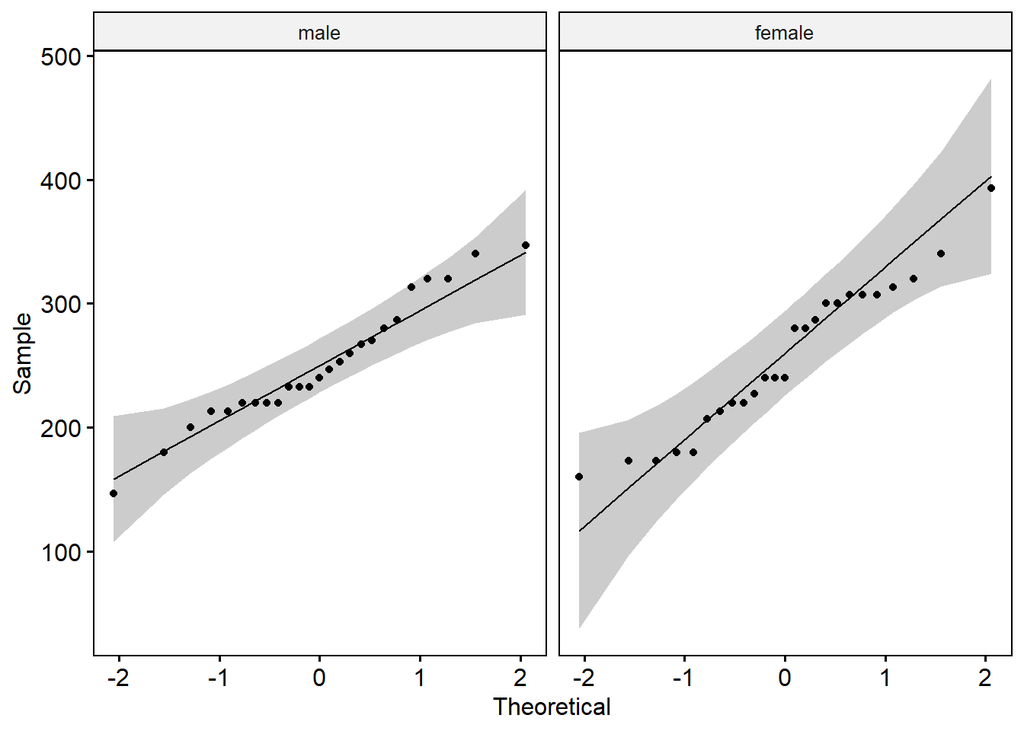

```r
threshold <- subset(threshold, threshold$Subject != 33)
ggqqplot(threshold, "Threshold", facet.by = "Sex")
```

### Results

Computing the ANOVA, we see no significant difference between men and women’s pain threshold. This lack of significance persists when an addition term is added to capture between subject variance, by the way.

```r
thresh.aov <- aov(Threshold ~ Sex, data = threshold)
summary(thresh.aov)
```

```
##             Df Sum Sq Mean Sq F value Pr(>F)
## Sex          1    343   343.2    0.11  0.741
## Residuals   48 149594  3116.5
```

Now we check that all ANOVA assumptions are met. First, independence of observations is met because each subject is either male or female, never both. Second, homogeneity of variance is tested with Levene’s test (note that a significant result indicates non-homogeneity and thus a violation of the assumption). Lastly, the Shapiro-Wilk test to gauge normality of the dataset (again, a significant result would indicate non-normality and a violation of the assumption of normality). For both of these tests, α = 0.05.

```r
leveneTest(Threshold ~ Sex, data = threshold)
```

```
## Levene's Test for Homogeneity of Variance (center = median)
##       Df F value Pr(>F)
## group  1  1.9325 0.1709
##       48
```

```r
shapiro.test(x = residuals(object = thresh.aov))
```

```
##
##  Shapiro-Wilk normality test
##
## data:  residuals(object = thresh.aov)
## W = 0.97958, p-value = 0.5342
```

$~$

$~$

## ANOVA on Verbal Pain Rating Data

Load in the Pain Rating data. This is sourced from two conditions, Perception and Control, as these were the only two conditions of the original study that collected verbal pain ratings (from 0-100, 100 being most intense pain).

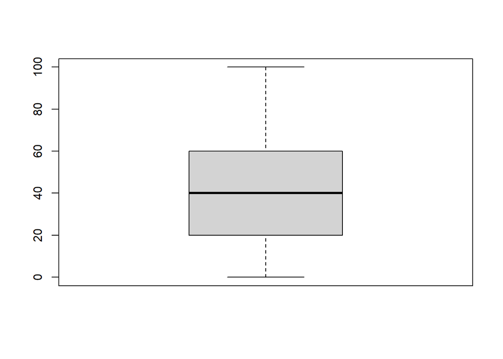

```r
R1 <- read_csv("Data/Perception_ratings.csv", col_types = cols(Sex = col_factor(
                                                          levels = c("male", "female")),
                                                          Stim = col_factor(
                                                          levels = c("low", "med", "high"))))
R1$Condition <- "Perception"
R2 <- read_csv("Data/Control_ratings.csv", col_types = cols(Sex = col_factor(
                                                       levels = c("male", "female")),
                                                       Stim = col_factor(
                                                       levels = c("low", "med", "high"))))
R2$Condition <- "Control"

ratings <- rbind(R1, R2)
ratings <- subset(ratings, ratings$Subject!=18)  # exclude subject 18 (DNF motor)
ratings <- ratings[!(ratings$Pain %in% boxplot(ratings$Pain)$out),]  # remove rows with outliers
```

```r
print("Sample Size")
```

```
## [1] "Sample Size"
```

```r
print(length(ratings$Pain))
```

```
## [1] 5998
```

```r
emm_options(pbkrtest.limit = 5000)
ratings <- na.omit(ratings)
ratings <- ratings[sample(nrow(ratings), 5000), ]
```

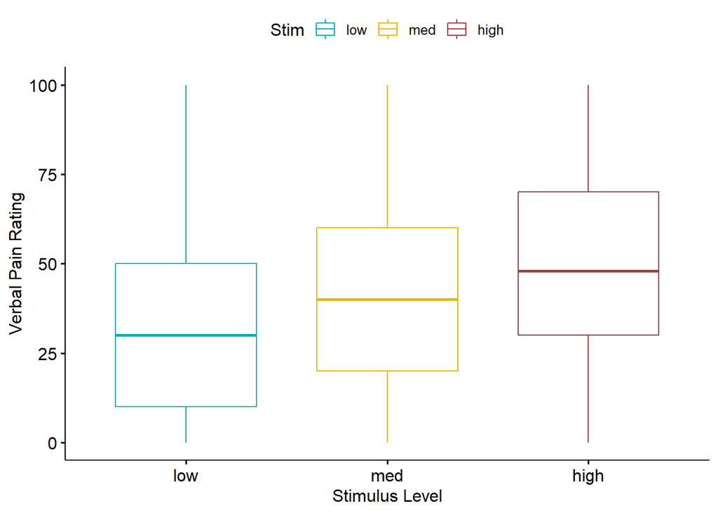

```r
ggboxplot(ratings, x = "Stim", y = "Pain",
          color = "Stim", palette = c("#00AFBB", "#E7B800", "#A03D41"),
          ylab = "Verbal Pain Rating", xlab = "Stimulus Level",
          order = c("low", "med", "high"))
```

```r
for (i in c("male", "female")) {
  print(table(ratings$Sex))
  for (j in c("low", "med", "high")){
    print(table(ratings$Stim))
    for (k in c("Perception", "Control")){
      print(table(ratings$Condition))
      m <- mean(subset(ratings, ratings$Sex==i & ratings$Stim==j & ratings$Condition==k)$Pain, na.rm = TRUE)
      s <- sd(subset(ratings, ratings$Sex==i & ratings$Stim==j & ratings$Condition==k)$Pain, na.rm = TRUE)
      print(sprintf("%s %s %s - %s (%s)", i, j, k, round(m, digits = 1), round(s, digits = 1)))
    }
  }
}
```

```
##
##   male female
##   2504   2496
##
##  low  med high
## 1645 1686 1669
##
##    Control Perception
##       2460       2540
## [1] "male low Perception - 38.2 (25.3)"
##
##    Control Perception
##       2460       2540
## [1] "male low Control - 39.1 (24.1)"
##
##  low  med high
## 1645 1686 1669
##
##    Control Perception
##       2460       2540
## [1] "male med Perception - 44 (24.6)"
##
##    Control Perception
##       2460       2540
## [1] "male med Control - 44.1 (23.5)"
##
##  low  med high
## 1645 1686 1669
##
##    Control Perception
##       2460       2540
## [1] "male high Perception - 49.4 (23.1)"
##
##    Control Perception
##       2460       2540
## [1] "male high Control - 50.8 (22.1)"
##
##   male female
##   2504   2496
##
```

[output cut: 17 more lines]

```
##
##    Control Perception
##       2460       2540
## [1] "female med Control - 39.1 (25.1)"
##
##  low  med high
## 1645 1686 1669
##
##    Control Perception
##       2460       2540
## [1] "female high Perception - 42.6 (26.5)"
##
##    Control Perception
##       2460       2540
## [1] "female high Control - 46.4 (26.8)"
```

### Results

To know if there is a statistical difference, we must model pain ratings as a factor of sex, but control for the effects of stimulus and Condition. Furthermore, we introduce a repeated-measures aspect to account for individual variances in subject pain perception.

```r
pain.model <- aov_ez(id = "Subject",
                     dv = "Pain",
                     data = ratings,
                     between = "Sex",
                     within = c("Stim", "Condition"),
                     fun_aggregate = mean)
knitr::kable(nice(pain.model))
```

| Effect | df | MSE | F | ges | p.value |
| --- | --- | --- | --- | --- | --- |
| Sex | 1, 48 | 2017.31 | 1.72 | .030 | .196 |
| Stim | 1.25, 59.79 | 52.77 | 126.82 *** | .070 | <.001 |
| Sex:Stim | 1.25, 59.79 | 52.77 | 2.39 | .001 | .121 |
| Condition | 1, 48 | 202.74 | 1.11 | .002 | .296 |
| Sex:Condition | 1, 48 | 202.74 | 0.49 | <.001 | .489 |
| Stim:Condition | 1.76, 84.48 | 18.81 | 1.17 | <.001 | .310 |
| Sex:Stim:Condition | 1.76, 84.48 | 18.81 | 0.33 | <.001 | .694 |

```r
post.hoc <- emmeans(pain.model, ~ Stim)  # significant main effect of Stimulus
print(summary(as.glht(pairs(post.hoc)), test=adjusted("bonferroni")))
```

```
##
##   Simultaneous Tests for General Linear Hypotheses
##
## Linear Hypotheses:
##                 Estimate Std. Error t value Pr(>|t|)
## low - med == 0   -6.6688     0.6021 -11.075 2.40e-14 ***
## low - high == 0 -12.9109     1.0802 -11.952 1.33e-15 ***
## med - high == 0  -6.2421     0.6654  -9.381 5.90e-12 ***
## ---
## Signif. codes:  0 '***' 0.001 '**' 0.01 '*' 0.05 '.' 0.1 ' ' 1
## (Adjusted p values reported -- bonferroni method)
```

1. Visualization is a safer way to confirm normality for such a high sample size

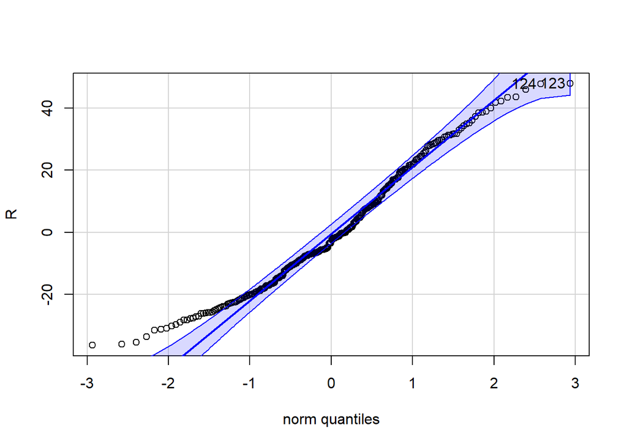

```
## [1] 123 124
```

```r
R = residuals(pain.model)
qqPlot(R)
```

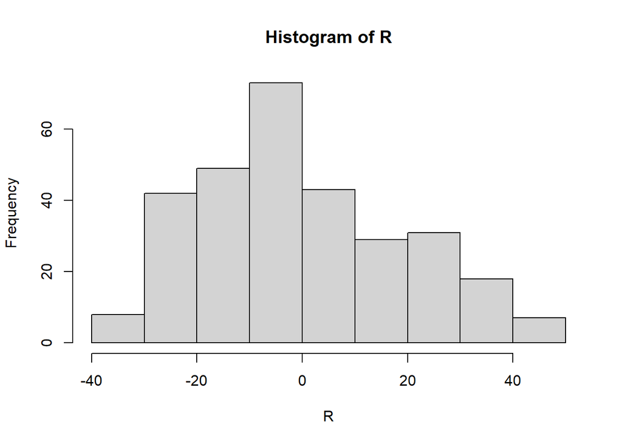

```r
hist(R)
```

2. Homogeneity of Variance (Levene’s test), p < 0.05 is non-homogeneous, but if there is little to no group imbalance (*ex* between male/female) this is acceptable.

```r
leveneTest(Pain ~ Sex * Stim * Condition, data = ratings)
```

```
## Levene's Test for Homogeneity of Variance (center = median)
##         Df F value    Pr(>F)
## group   11  4.4071 1.268e-06 ***
##       4988
## ---
## Signif. codes:  0 '***' 0.001 '**' 0.01 '*' 0.05 '.' 0.1 ' ' 1
```

```r
table(ratings$Sex)
```

```
##
##   male female
##   2504   2496
```

```r
table(ratings$Stim)
```

```
##
##  low  med high
## 1645 1686 1669
```

```r
table(ratings$Condition)
```

```
##
##    Control Perception
##       2460       2540
```

3. Sphericity is corrected for with a Greenhouse-Geisser correction when needed.

Plot our results

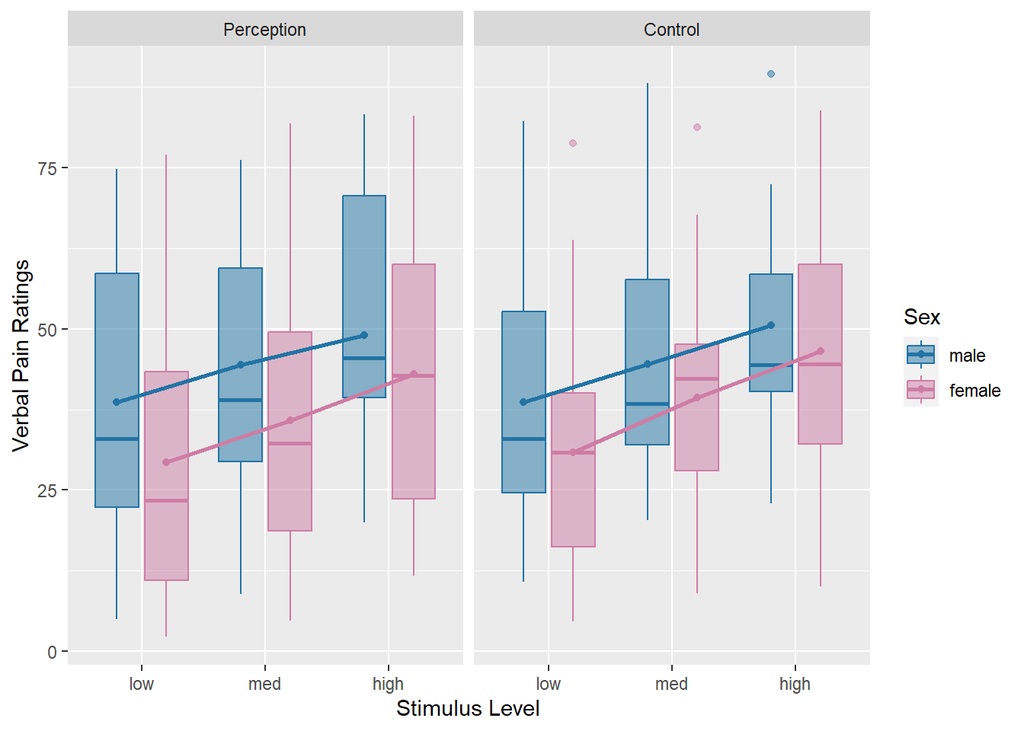

```r
afex_plot(pain.model, x = "Stim", trace = "Sex",
          panel = "Condition", error = "none",
          mapping = c("color", "fill"),
          data_geom = geom_boxplot, data_arg = list(width = 0.7),
          point_arg = list(size = 1.5), line_arg = list(size = 1),
          dodge = 0.8) +
  ylab("Verbal Pain Ratings") +
  xlab("Stimulus Level") +
  scale_fill_manual(values = c("#2274A5", "#CE7DA5")) +
  scale_color_manual(values = c("#2274A5", "#CE7DA5"))
```